# Hands on 1

##### Resting blood pressure (trestbps) and Diagnosis of heart disease (num)

```r
# Descriptive analysis
by(heart_disease_dataset$trestbps, heart_disease_dataset$num,summary)
```

```
## heart_disease_dataset$num: Absence
##    Min. 1st Qu.  Median    Mean 3rd Qu.    Max.
##    94.0   120.0   130.0   129.2   140.0   180.0
## ------------------------------------------------------------
## heart_disease_dataset$num: Presence
##    Min. 1st Qu.  Median    Mean 3rd Qu.    Max.
##   100.0   120.0   130.0   134.6   145.0   200.0
```

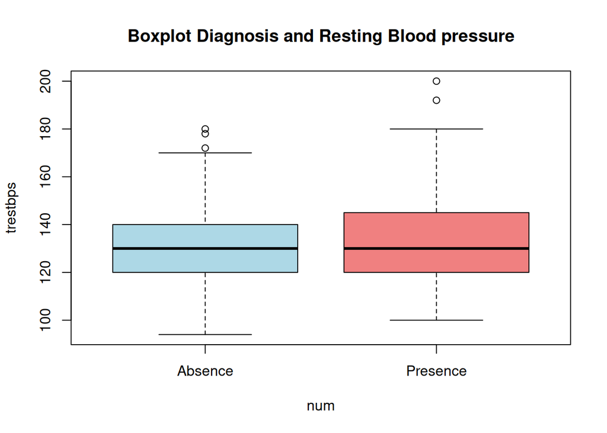

```r
boxplot(trestbps ~ num,
        heart_disease_dataset, main='Boxplot Diagnosis and Resting Blood pressure',col=c('lightblue','lightcoral'))
```

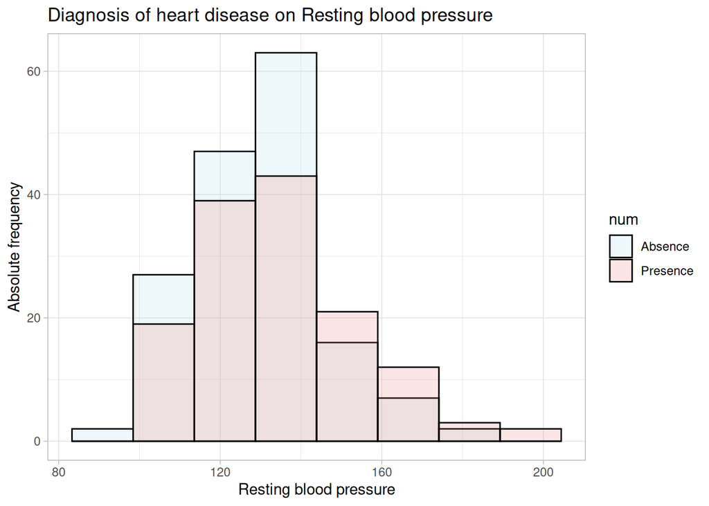

```r
ggplot(data = heart_disease_dataset, aes(x = trestbps, fill = num)) +
  geom_histogram(alpha = .2, position = "identity", color = "black", bins = 8) + labs(x = "Resting blood pressure", y = "Absolute frequency", title = "Diagnosis of heart disease on Resting blood pressure") +
  scale_fill_manual(values = c('lightblue', 'lightcoral')) +
  theme_light()
```

```r
## T-test
#Checking normal distribution of the data
shapiro.test(heart_disease_dataset$trestbps[heart_disease_dataset$num=="Absence"]) #Does not follow a normal distribution
```

```
##
##  Shapiro-Wilk normality test
##
## data:  heart_disease_dataset$trestbps[heart_disease_dataset$num == "Absence"]
## W = 0.97842, p-value = 0.01156
```

```r
shapiro.test(heart_disease_dataset$trestbps[heart_disease_dataset$num=="Presence"])
```

```
##
##  Shapiro-Wilk normality test
##
## data:  heart_disease_dataset$trestbps[heart_disease_dataset$num == "Presence"]
## W = 0.95322, p-value = 0.0001173
```

```r
#Does not follow a normal distribution
#Checking the variance
var.test(trestbps~num,data=heart_disease_dataset) #homogeneity of variances
```

```
##
##  F test to compare two variances
##
## data:  trestbps by num
## F = 0.74542, num df = 163, denom df = 138, p-value = 0.07161
## alternative hypothesis: true ratio of variances is not equal to 1
## 95 percent confidence interval:
##  0.5390996 1.0262207
## sample estimates:
## ratio of variances
##          0.7454198
```

```r
t.test(age~num,data=heart_disease_dataset,var.equal = TRUE) #there is statistical difference
```

[output not shown]

Both variables do not follow a normal distribution but as mentioned with the age variable, we can perform a t-test as both groups have more than 30 individuals.

##### Cholesterol levels (chol) and Diagnosis of heart disease (num)

We need to remember for this analysis we have to do it with the subset for cholesterol we did (data_chol) that removed the outliers from the variable.

```r
# Descriptive analysis
by(data_chol$chol, data_chol$num,summary)
```

```
## data_chol$num: Absence
##    Min. 1st Qu.  Median    Mean 3rd Qu.    Max.
##   126.0   208.0   234.0   238.6   265.0   360.0
## ------------------------------------------------------------
## data_chol$num: Presence
##    Min. 1st Qu.  Median    Mean 3rd Qu.    Max.
##   131.0   217.0   249.0   249.2   283.0   353.0
```

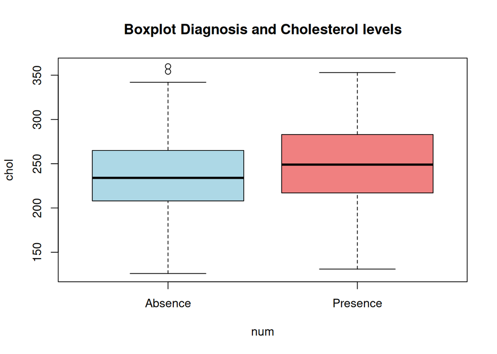

```r
boxplot(chol ~ num,
        data_chol, main='Boxplot Diagnosis and Cholesterol levels',col=c('lightblue','lightcoral'))
```

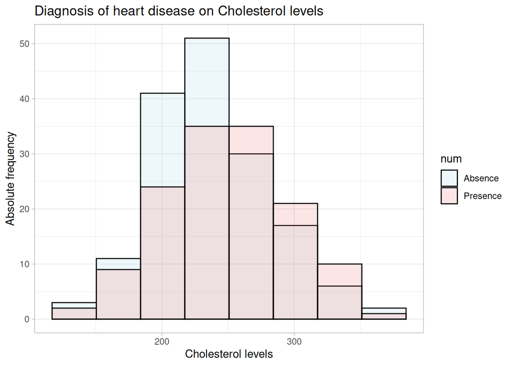

```r
ggplot(data = data_chol, aes(x = chol, fill = num)) +
  geom_histogram(alpha = .2, position = "identity", color = "black", bins = 8) + labs(x = "Cholesterol levels", y = "Absolute frequency", title = "Diagnosis of heart disease on Cholesterol levels") +
  scale_fill_manual(values = c('lightblue', 'lightcoral')) +
  theme_light()
```

```r
## T-test
#Checking normal distribution of the data
shapiro.test(data_chol$chol[data_chol$num=="Absence"]) # Follows a normal distribution
```

```
##
##  Shapiro-Wilk normality test
##
## data:  data_chol$chol[data_chol$num == "Absence"]
## W = 0.98428, p-value = 0.06531
```

```r
shapiro.test(data_chol$chol[data_chol$num=="Presence"]) # Follows a normal distribution
```

```
##
##  Shapiro-Wilk normality test
##
## data:  data_chol$chol[data_chol$num == "Presence"]
## W = 0.99281, p-value = 0.7184
```

```r
#Checking the variance
var.test(chol~num,data=data_chol) #Homogeneity of variances
```

```
##
##  F test to compare two variances
##
## data:  chol by num
## F = 0.90417, num df = 160, denom df = 136, p-value = 0.5386
## alternative hypothesis: true ratio of variances is not equal to 1
## 95 percent confidence interval:
##  0.6521737 1.2481250
## sample estimates:
## ratio of variances
##          0.9041689
```

```r
t.test(chol~num,data=data_chol,var.equal = TRUE) # There is statistical difference
```

```
##
##  Two Sample t-test
##
## data:  chol by num
## t = -2.0283, df = 296, p-value = 0.04343
## alternative hypothesis: true difference in means between group Absence and group Presence is not equal to 0
## 95 percent confidence interval:
##  -20.8232383  -0.3140877
## sample estimates:
##  mean in group Absence mean in group Presence
##               238.6211               249.1898
```

There is an statistical significance regarding cholesterol levels and the diagnosis, with a threshold of 0.05.

##### Fasting blood sugar (fbs) and Diagnosis of heart disease (num)

```r
# Absolute Frequences
fbs_Diagnosis_table<-table(heart_disease_dataset$num, heart_disease_dataset$fbs)
(fbs_Diagnosis_table_total <- addmargins(fbs_Diagnosis_table))
```

```
##
##            High Low Sum
##   Absence    23 141 164
##   Presence   22 117 139
##   Sum        45 258 303
```

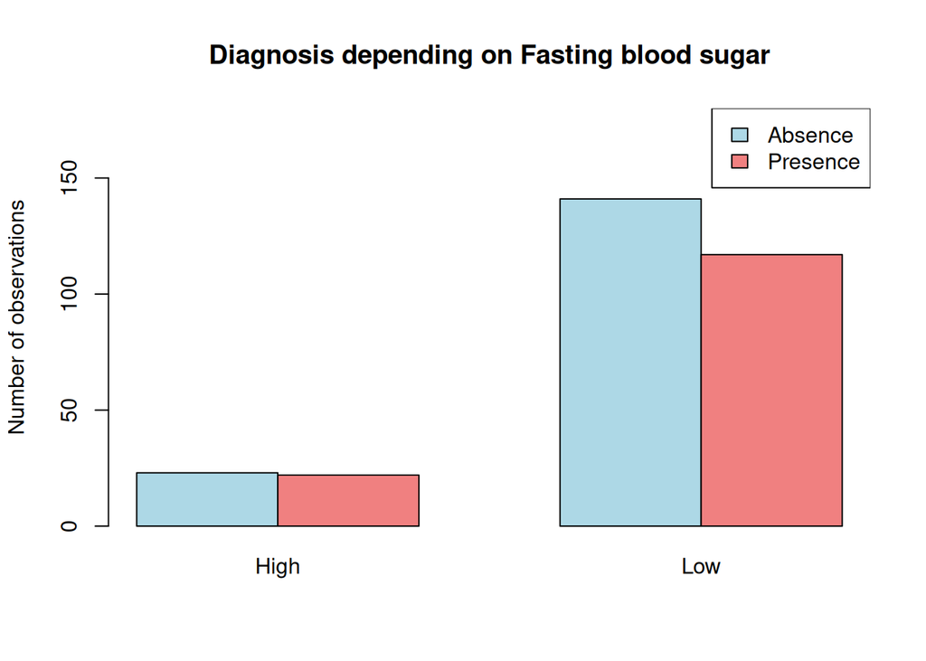

```r
barplot(fbs_Diagnosis_table,
        col = c('lightblue', 'lightcoral'),
        beside = TRUE,
        ylim = c(0, 180), ylab = "Number of observations", main = "Diagnosis depending on Fasting blood sugar");legend(x = "topright",legend = unique(heart_disease_dataset$num),  fill = c('lightblue', 'lightcoral'))
```

```r
#Relative Frequences tables
(fbs_Diagnosis_table_freqs <- prop.table(fbs_Diagnosis_table))
```

```
##
##                  High        Low
##   Absence  0.07590759 0.46534653
##   Presence 0.07260726 0.38613861
```

```r
(fbs_Diagnosis_table_freqs_total <- addmargins(fbs_Diagnosis_table_freqs))
```

```
##
##                  High        Low        Sum
##   Absence  0.07590759 0.46534653 0.54125413
##   Presence 0.07260726 0.38613861 0.45874587
##   Sum      0.14851485 0.85148515 1.00000000
```

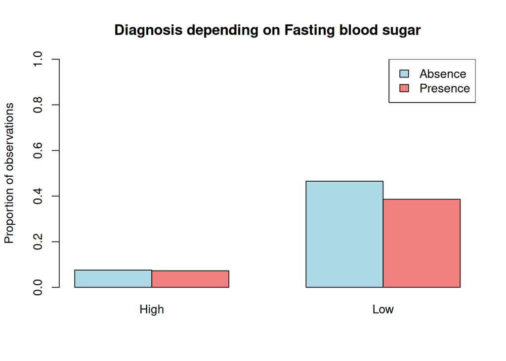

```r
barplot(fbs_Diagnosis_table_freqs,
        col = c('lightblue', 'lightcoral'),
        beside = TRUE,
        ylim = c(0, 1), ylab = "Proportion of observations", main = "Diagnosis depending on Fasting blood sugar");legend(x = "topright",legend = unique(heart_disease_dataset$num),  fill = c('lightblue', 'lightcoral'))
```

```r
#Fisher test
fisher.test(fbs_Diagnosis_table, alternative = "two.sided") #significative
```

```
##
##  Fisher's Exact Test for Count Data
##
## data:  fbs_Diagnosis_table
## p-value = 0.7463
## alternative hypothesis: true odds ratio is not equal to 1
## 95 percent confidence interval:
##  0.4377343 1.7241486
## sample estimates:
## odds ratio
##  0.8679152
```

```r
assocstats(fbs_Diagnosis_table)
```

```
##                      X^2 df P(> X^2)
## Likelihood Ratio 0.19296  1  0.66046
## Pearson          0.19339  1  0.66011
##
## Phi-Coefficient   : 0.025
## Contingency Coeff.: 0.025
## Cramer's V        : 0.025
```

For this analysis we do not see any significant difference between the diagnosis and the fasting blood sugar.

##### Resting electrocardiographic results (restecg) and Diagnosis of heart disease (num)

For this variable we also have to remember we did a subset to take out one of the groups as it only had 4 individuals. So for this analysis the data set will be “data_restecg”

```r
# Absolute Frequences
restecg_Diagnosis_table<-table(data_restecg$num,data_restecg$restecg)
(restecg_Diagnosis_table_total <- addmargins(restecg_Diagnosis_table))
```

```
##
##            Normal Left ventricular hypertrophy Sum
##   Absence      95                           68 163
##   Presence     56                           80 136
##   Sum         151                          148 299
```

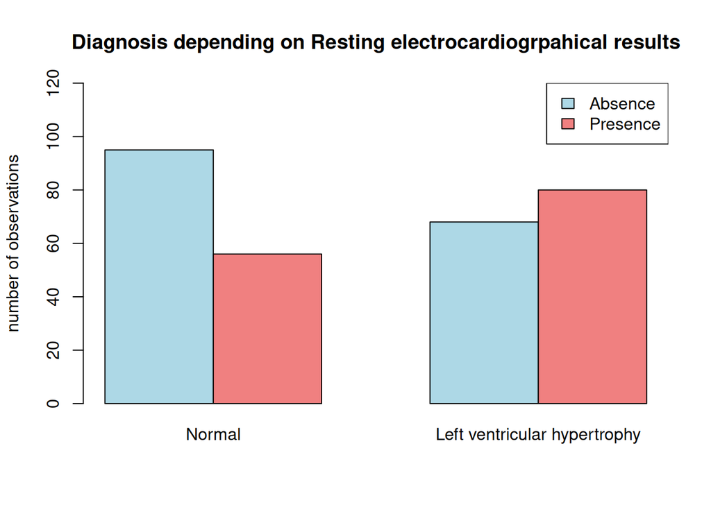

```r
barplot(restecg_Diagnosis_table,
        col = c('lightblue', 'lightcoral'),
        beside = TRUE,
        ylim = c(0, 120), ylab = "number of observations", main = "Diagnosis depending on Resting electrocardiogrpahical results");legend(x = "topright",legend = unique(data_restecg$num),  fill = c('lightblue', 'lightcoral'))
```

```r
#Relative Frequences tables
(restecg_Diagnosis_table_freqs <- prop.table(restecg_Diagnosis_table))
```

```
##
##               Normal Left ventricular hypertrophy
##   Absence  0.3177258                    0.2274247
##   Presence 0.1872910                    0.2675585
```

```r
(restecg_Diagnosis_table_freqs_total <- addmargins(restecg_Diagnosis_table_freqs))
```

```
##
##               Normal Left ventricular hypertrophy       Sum
##   Absence  0.3177258                    0.2274247 0.5451505
##   Presence 0.1872910                    0.2675585 0.4548495
##   Sum      0.5050167                    0.4949833 1.0000000
```

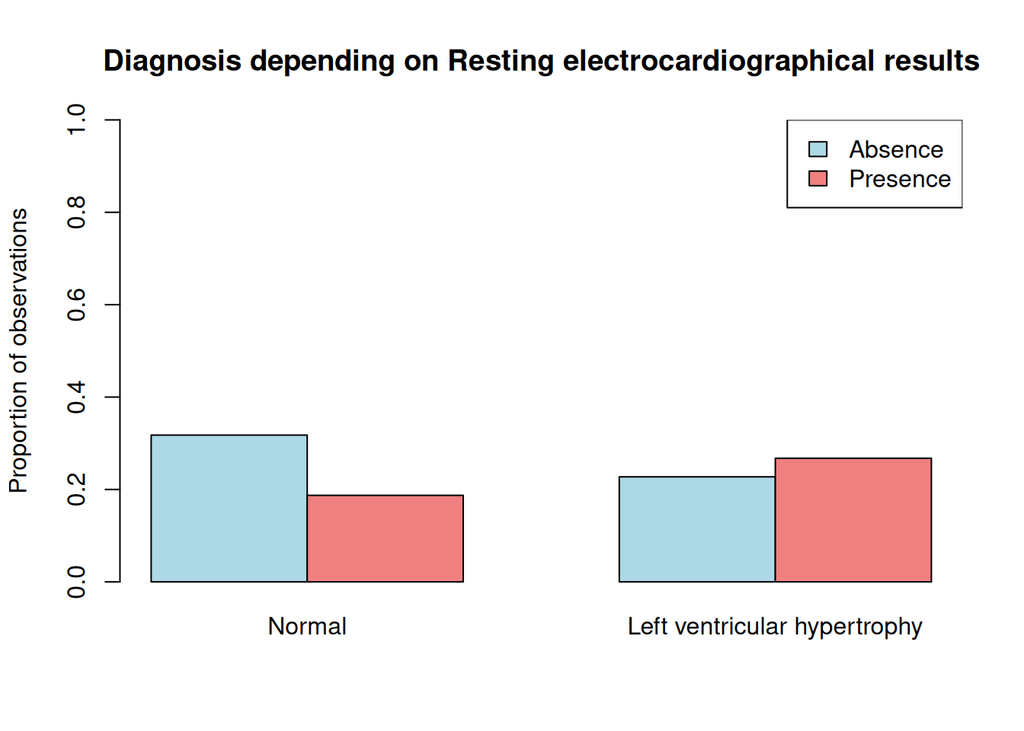

```r
barplot(restecg_Diagnosis_table_freqs,
        col = c('lightblue', 'lightcoral'),
        beside = TRUE,
        ylim = c(0, 1), ylab = "Proportion of observations", main = "Diagnosis depending on Resting electrocardiographical results");legend(x = "topright",legend = unique(data_restecg$num),  fill = c('lightblue', 'lightcoral'))
```

```r
#Fisher test
fisher.test(restecg_Diagnosis_table, alternative = "two.sided") #significative
```

```
##
##  Fisher's Exact Test for Count Data
##
## data:  restecg_Diagnosis_table
## p-value = 0.00371
## alternative hypothesis: true odds ratio is not equal to 1
## 95 percent confidence interval:
##  1.225197 3.253889
## sample estimates:
## odds ratio
##   1.991113
```

```r
assocstats(restecg_Diagnosis_table)
```

```
##                     X^2 df  P(> X^2)
## Likelihood Ratio 8.7205  1 0.0031465
## Pearson          8.6785  1 0.0032199
##
## Phi-Coefficient   : 0.17
## Contingency Coeff.: 0.168
## Cramer's V        : 0.17
```

```r
#Chi-squared test
res<-chisq.test(restecg_Diagnosis_table)
res
```

```
##
##  Pearson's Chi-squared test with Yates' continuity correction
##
## data:  restecg_Diagnosis_table
## X-squared = 8.0077, df = 1, p-value = 0.004658
```

```r
res$observed
```

```
##
##            Normal Left ventricular hypertrophy
##   Absence      95                           68
##   Presence     56                           80
```

```r
res$expected
```

```
##
##              Normal Left ventricular hypertrophy
##   Absence  82.31773                     80.68227
##   Presence 68.68227                     67.31773
```

```r
res$residuals
```

```
##
##               Normal Left ventricular hypertrophy
##   Absence   1.397817                    -1.411913
##   Presence -1.530294                     1.545726
```

We can see how there is an statistical significant difference between the resting cardiographical results and the diagnosis. It seems that having a normal cardiographical result is related to an absence of cardiac disease, while a left ventricular hypertrophy seems to have higher incidence of diagnosed patients.

##### Maximum heart rate achieved (thalach) and Diagnosis of heart disease (num)

For this analysis we will use the subset “data_talach” as we have previously taken out some outliers.

```r
# Descriptive analysis
by(data_thalach$thalach, data_thalach$num,summary)
```

```
## data_thalach$num: Absence
##    Min. 1st Qu.  Median    Mean 3rd Qu.    Max.
##    96.0   148.8   161.0   158.4   172.0   202.0
## ------------------------------------------------------------
## data_thalach$num: Presence
##    Min. 1st Qu.  Median    Mean 3rd Qu.    Max.
##    88.0   125.0   142.0   139.8   156.8   195.0
```

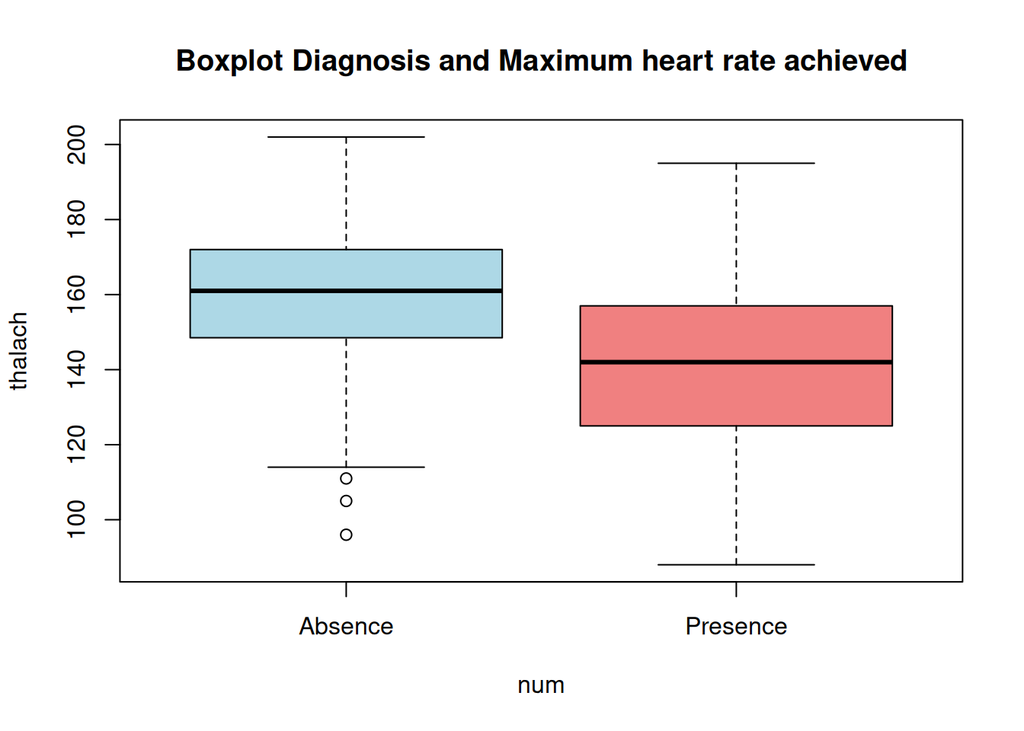

```r
boxplot(thalach ~ num,
        data_thalach, main='Boxplot Diagnosis and Maximum heart rate achieved',col=c('lightblue','lightcoral'))
```

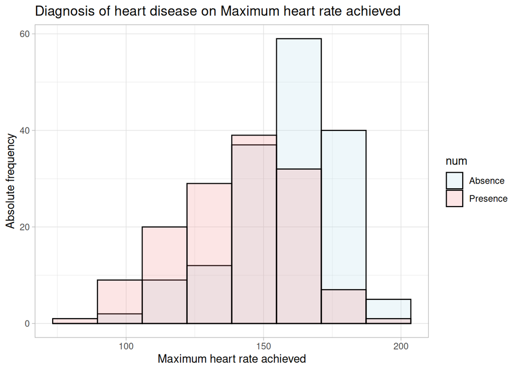

```r
ggplot(data = data_thalach, aes(x = thalach, fill = num)) +
  geom_histogram(alpha = .2, position = "identity", color = "black", bins = 8) + labs(x = "Maximum heart rate achieved", y = "Absolute frequency", title = "Diagnosis of heart disease on Maximum heart rate achieved") +
  scale_fill_manual(values = c('lightblue', 'lightcoral')) +
  theme_light()
```

```r
## T-test
#Checking normal distribution of the data
shapiro.test(data_thalach$chol[data_thalach$num=="Absence"]) # Does not follow a normal distribution
```

```
##
##  Shapiro-Wilk normality test
##
## data:  data_thalach$chol[data_thalach$num == "Absence"]
## W = 0.89734, p-value = 2.878e-09
```

```r
shapiro.test(data_thalach$chol[data_thalach$num=="Presence"]) # Follows a normal distribution
```

```
##
##  Shapiro-Wilk normality test
##
## data:  data_thalach$chol[data_thalach$num == "Presence"]
## W = 0.98978, p-value = 0.4087
```

```r
#Checking the variance
var.test(thalach~num,data=data_thalach) #Homogeneity of variances
```

```
##
##  F test to compare two variances
##
## data:  thalach by num
## F = 0.76805, num df = 163, denom df = 137, p-value = 0.1061
## alternative hypothesis: true ratio of variances is not equal to 1
## 95 percent confidence interval:
##  0.5550509 1.0579407
## sample estimates:
## ratio of variances
##          0.7680476
```

```r
t.test(thalach~num,data=data_thalach,var.equal = TRUE) # There is statistical difference
```

```
##
##  Two Sample t-test
##
## data:  thalach by num
## t = 7.8724, df = 300, p-value = 6.399e-14
## alternative hypothesis: true difference in means between group Absence and group Presence is not equal to 0
## 95 percent confidence interval:
##  13.96877 23.28008
## sample estimates:
##  mean in group Absence mean in group Presence
##               158.3780               139.7536
```

##### Exercise induced angina (exang) and Diagnosis of heart disease (num)

```r
# Absolute Frequences
exang_Diagnosis_table<-table(heart_disease_dataset$num, heart_disease_dataset$exang)
(exang_Diagnosis_table_total <- addmargins(exang_Diagnosis_table))
```

```
##
##             No Yes Sum
##   Absence  141  23 164
##   Presence  63  76 139
##   Sum      204  99 303
```

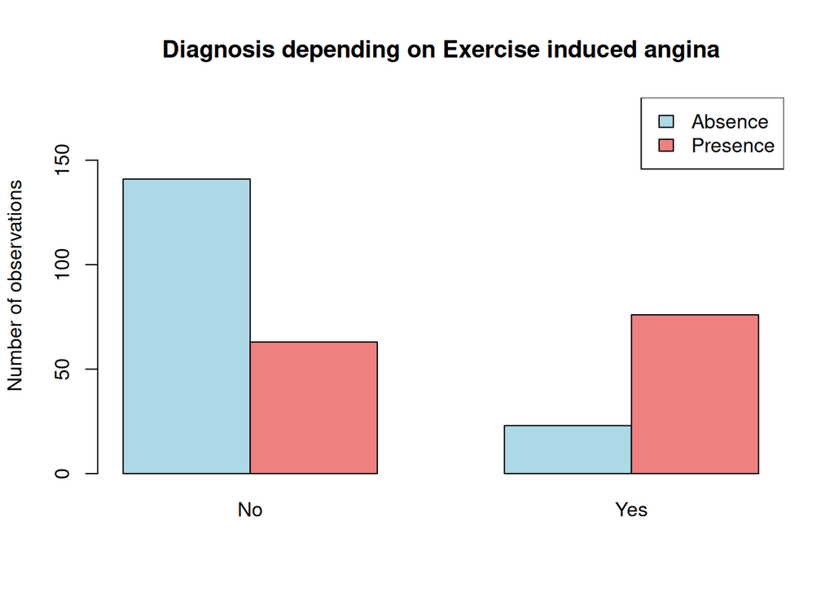

```r
barplot(exang_Diagnosis_table,
        col = c('lightblue', 'lightcoral'),
        beside = TRUE,
        ylim = c(0, 180), ylab = "Number of observations", main = "Diagnosis depending on Exercise induced angina");legend(x = "topright",legend = unique(heart_disease_dataset$num),  fill = c('lightblue', 'lightcoral'))
```

```r
#Relative Frequences tables
(exang_Diagnosis_table_freqs <- prop.table(exang_Diagnosis_table))
```

```
##
##                    No        Yes
##   Absence  0.46534653 0.07590759
##   Presence 0.20792079 0.25082508
```

```r
(exang_Diagnosis_table_freqs_total <- addmargins(exang_Diagnosis_table_freqs))
```

```
##
##                    No        Yes        Sum
##   Absence  0.46534653 0.07590759 0.54125413
##   Presence 0.20792079 0.25082508 0.45874587
##   Sum      0.67326733 0.32673267 1.00000000
```

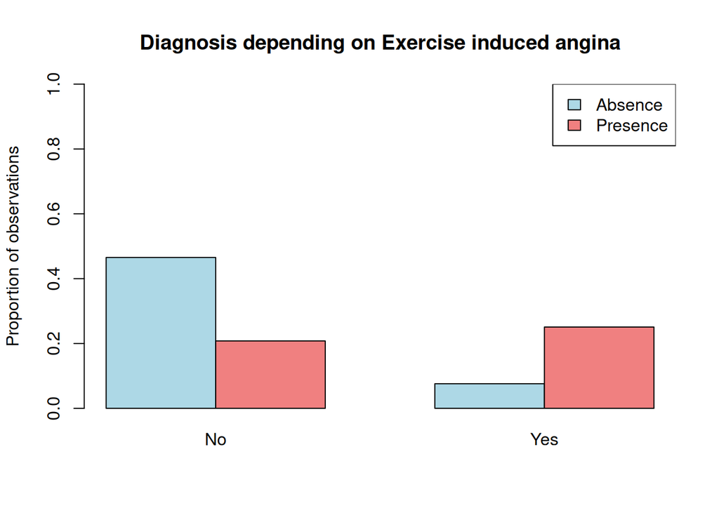

```r
barplot(exang_Diagnosis_table_freqs,
        col = c('lightblue', 'lightcoral'),
        beside = TRUE,
        ylim = c(0, 1), ylab = "Proportion of observations", main = "Diagnosis depending on Exercise induced angina");legend(x = "topright",legend = unique(heart_disease_dataset$num),  fill = c('lightblue', 'lightcoral'))
```

```r
#Fisher test
fisher.test(exang_Diagnosis_table, alternative = "two.sided") #significative
```

```
##
##  Fisher's Exact Test for Count Data
##
## data:  exang_Diagnosis_table
## p-value = 4.029e-14
## alternative hypothesis: true odds ratio is not equal to 1
## 95 percent confidence interval:
##   4.125272 13.457280
## sample estimates:
## odds ratio
##   7.340229
```

```r
assocstats(exang_Diagnosis_table)
```

```
##                     X^2 df   P(> X^2)
## Likelihood Ratio 58.445  1 2.0872e-14
## Pearson          56.519  1 5.5622e-14
##
## Phi-Coefficient   : 0.432
## Contingency Coeff.: 0.396
## Cramer's V        : 0.432
```

```r
#Chi-squared test
res<-chisq.test(exang_Diagnosis_table)
res
```

```
##
##  Pearson's Chi-squared test with Yates' continuity correction
##
## data:  exang_Diagnosis_table
## X-squared = 54.686, df = 1, p-value = 1.414e-13
```

```r
res$observed
```

```
##
##             No Yes
##   Absence  141  23
##   Presence  63  76
```

```r
res$expected
```

```
##
##                   No      Yes
##   Absence  110.41584 53.58416
##   Presence  93.58416 45.41584
```

```r
res$residuals
```

```
##
##                   No       Yes
##   Absence   2.910589 -4.178095
##   Presence -3.161516  4.538296
```

Given the results of the statistical tests we can say there is a statistical difference in the diagnosis regarding the exercise induced angina. Not having an Angina implies an absence of heart disease diagnosis while having an angina seems has a higher incidence of diagnosed individuals.

##### ST depression induced by exercise, relative to rest (oldpeak) and Diagnosis of heart disease (num)

```r
# Descriptive analysis
by(heart_disease_dataset$oldpeak, heart_disease_dataset$num,summary)
```

```
## heart_disease_dataset$num: Absence
##    Min. 1st Qu.  Median    Mean 3rd Qu.    Max.
##  0.0000  0.0000  0.2000  0.5866  1.0250  4.2000
## ------------------------------------------------------------
## heart_disease_dataset$num: Presence
##    Min. 1st Qu.  Median    Mean 3rd Qu.    Max.
##   0.000   0.550   1.400   1.574   2.500   6.200
```

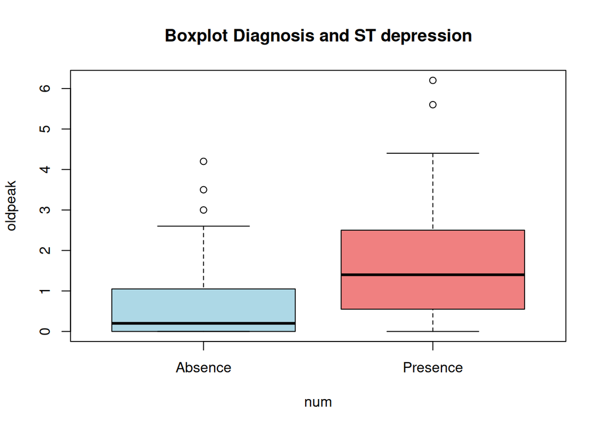

```r
boxplot(oldpeak ~ num,
        heart_disease_dataset, main='Boxplot Diagnosis and ST depression',col=c('lightblue','lightcoral'))
```

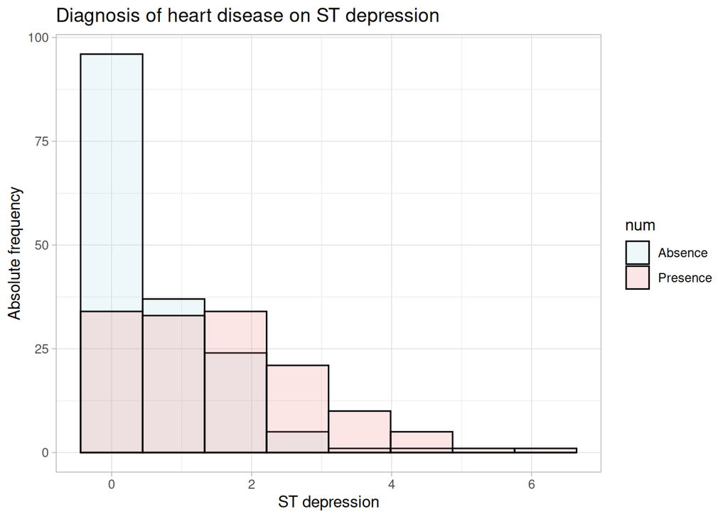

```r
ggplot(data = heart_disease_dataset, aes(x = oldpeak, fill = num)) +
  geom_histogram(alpha = .2, position = "identity", color = "black", bins = 8) + labs(x = "ST depression", y = "Absolute frequency", title = "Diagnosis of heart disease on ST depression") +
  scale_fill_manual(values = c('lightblue', 'lightcoral')) +
  theme_light()
```

```r
## T-test
#Checking normal distribution of the data
shapiro.test(heart_disease_dataset$oldpeak[heart_disease_dataset$num=="Absence"]) # Does not follow a normal distribution
```

```
##
##  Shapiro-Wilk normality test
##
## data:  heart_disease_dataset$oldpeak[heart_disease_dataset$num == "Absence"]
## W = 0.77148, p-value = 1.034e-14
```

```r
shapiro.test(heart_disease_dataset$oldpeak[heart_disease_dataset$num=="Presence"]) # Does not follow a normal distribution
```

```
##
##  Shapiro-Wilk normality test
##
## data:  heart_disease_dataset$oldpeak[heart_disease_dataset$num == "Presence"]
## W = 0.93031, p-value = 2.339e-06
```

```r
#Checking the variance
var.test(oldpeak~num,data=heart_disease_dataset) #no homogeneity of variances
```

```
##
##  F test to compare two variances
##
## data:  oldpeak by num
## F = 0.36017, num df = 163, denom df = 138, p-value = 5.944e-10
## alternative hypothesis: true ratio of variances is not equal to 1
## 95 percent confidence interval:
##  0.2604813 0.4958477
## sample estimates:
## ratio of variances
##          0.3601707
```

```r
t.test(oldpeak~num,data=heart_disease_dataset,var.equal = FALSE) #there is statistical difference
```

```
##
##  Welch Two Sample t-test
##
## data:  oldpeak by num
## t = -7.8234, df = 217.92, p-value = 2.195e-13
## alternative hypothesis: true difference in means between group Absence and group Presence is not equal to 0
## 95 percent confidence interval:
##  -1.2362942 -0.7387365
## sample estimates:
##  mean in group Absence mean in group Presence
##              0.5865854              1.5741007
```

There is an statistical difference between the ST depression induced by exercise, relative to rest when comparing diagnosed and non diagnosed groups of heart disease. It seems that higher number of ST depression induced by exercise imply a higher probability of being diagnosed.

##### Slope of the peak exercise ST segment (slope) and Diagnosis of heart disease (num)

```r
# Absolute Frequences
slope_Diagnosis_table<-table(heart_disease_dataset$num, heart_disease_dataset$slope)
(slope_Diagnosis_table_total <- addmargins(slope_Diagnosis_table))
```

```
##
##            Upsloping Flat Downsloping Sum
##   Absence        106   49           9 164
##   Presence        36   91          12 139
##   Sum            142  140          21 303
```

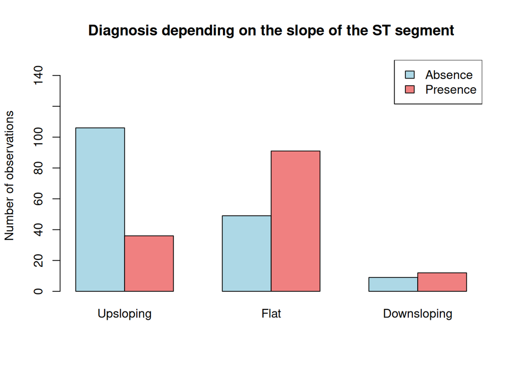

```r
barplot(slope_Diagnosis_table,
        col = c('lightblue', 'lightcoral'),
        beside = TRUE,
        ylim = c(0, 150), ylab = "Number of observations", main = "Diagnosis depending on the slope of the ST segment");legend(x = "topright",legend = unique(heart_disease_dataset$num),  fill = c('lightblue', 'lightcoral'))
```

```r
#Relative Frequences tables
(slope_Diagnosis_table_freqs <- prop.table(slope_Diagnosis_table))
```

```
##
##             Upsloping       Flat Downsloping
##   Absence  0.34983498 0.16171617  0.02970297
##   Presence 0.11881188 0.30033003  0.03960396
```

```r
(slope_Diagnosis_table_freqs_total <- addmargins(slope_Diagnosis_table_freqs))
```

```
##
##             Upsloping       Flat Downsloping        Sum
##   Absence  0.34983498 0.16171617  0.02970297 0.54125413
##   Presence 0.11881188 0.30033003  0.03960396 0.45874587
##   Sum      0.46864686 0.46204620  0.06930693 1.00000000
```

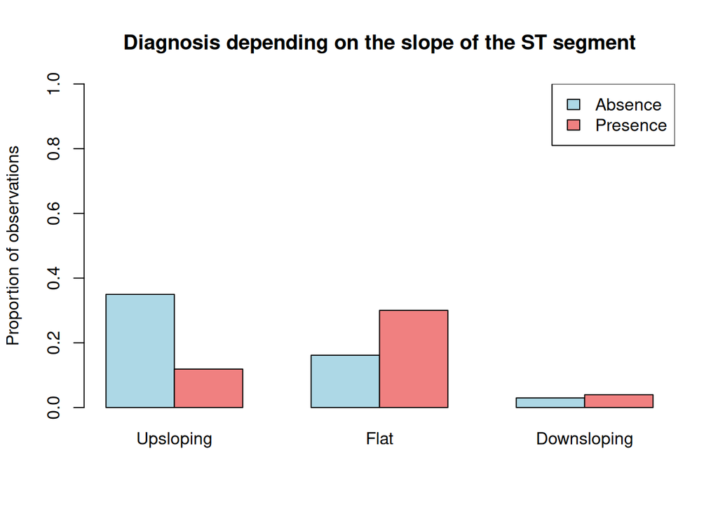

```r
barplot(slope_Diagnosis_table_freqs,
        col = c('lightblue', 'lightcoral'),
        beside = TRUE,
        ylim = c(0, 1), ylab = "Proportion of observations", main = "Diagnosis depending on the slope of the ST segment");legend(x = "topright",legend = unique(heart_disease_dataset$num),  fill = c('lightblue', 'lightcoral'))
```

```r
#Fisher test
fisher.test(slope_Diagnosis_table, alternative = "two.sided") #significative
```

```
##
##  Fisher's Exact Test for Count Data
##
## data:  slope_Diagnosis_table
## p-value = 2.989e-11
## alternative hypothesis: two.sided
```

```r
assocstats(slope_Diagnosis_table)
```

```
##                     X^2 df   P(> X^2)
## Likelihood Ratio 47.223  2 5.5688e-11
## Pearson          45.785  2 1.1429e-10
##
## Phi-Coefficient   : NA
## Contingency Coeff.: 0.362
## Cramer's V        : 0.389
```

```r
#Chi-squared test
res<-chisq.test(slope_Diagnosis_table)
res
```

```
##
##  Pearson's Chi-squared test
##
## data:  slope_Diagnosis_table
## X-squared = 45.785, df = 2, p-value = 1.143e-10
```

```r
res$observed
```

```
##
##            Upsloping Flat Downsloping
##   Absence        106   49           9
##   Presence        36   91          12
```

```r
res$expected
```

```
##
##            Upsloping     Flat Downsloping
##   Absence   76.85809 75.77558   11.366337
##   Presence  65.14191 64.22442    9.633663
```

```r
res$residuals
```

```
##
##             Upsloping       Flat Downsloping
##   Absence   3.3240940 -3.0759142  -0.7018855
##   Presence -3.6106702  3.3410944   0.7623963
```

As we see in the statistical tests, there are significant differences between the groups of the slope of the peak exercise ST segment, when relating them to the diagnosis. Also looking at the residuals we can see that the flat and upsloping groups are the ones contributing the most to the chi-squared results, while Downsloping seems to have a lower impact.

##### Number of major vessels colored by fluoroscopy (ca) and Diagnosis of heart disease (num)

For this analysis we previously created a subset called “data_ca” that does not have 4 individuals from which we did not have the number of major vessels.

```r
# Absolute Frequences
ca_Diagnosis_table<-table(data_ca$num,data_ca$ca)
(ca_Diagnosis_table_total <- addmargins(ca_Diagnosis_table))
```

```
##
##              0   1   2   3 Sum
##   Absence  130  21   7   3 161
##   Presence  46  44  31  17 138
##   Sum      176  65  38  20 299
```

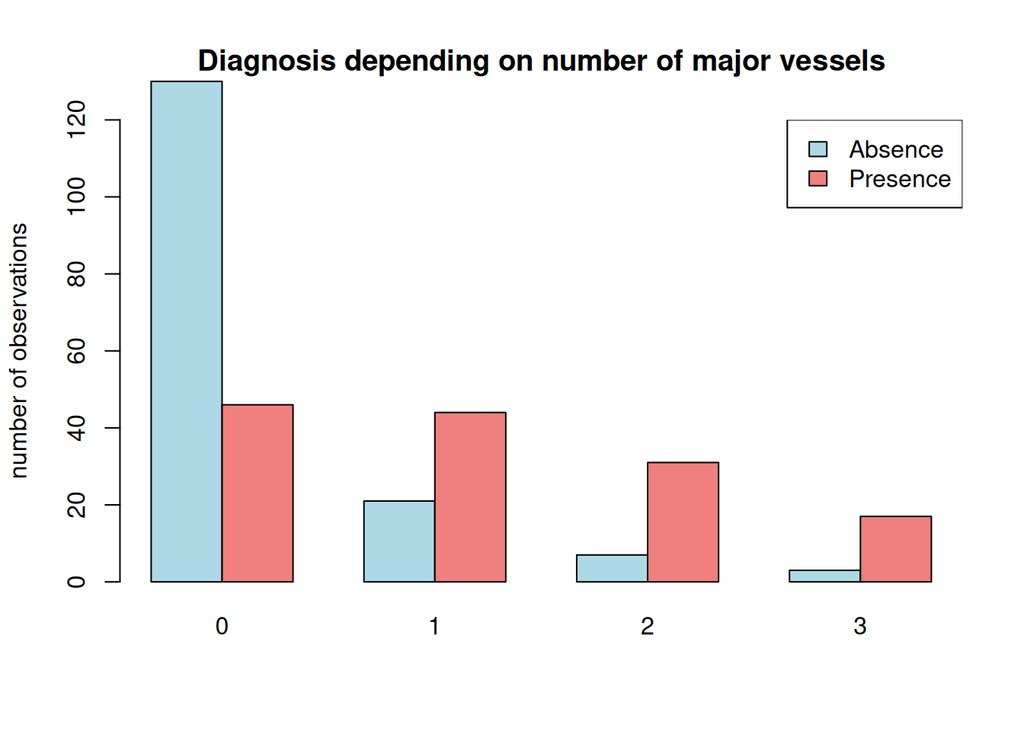

```r
barplot(ca_Diagnosis_table,
        col = c('lightblue', 'lightcoral'),
        beside = TRUE,
        ylim = c(0, 120), ylab = "number of observations", main = "Diagnosis depending on number of major vessels");legend(x = "topright",legend = unique(data_ca$num),  fill = c('lightblue', 'lightcoral'))
```

```r
#Relative Frequences tables
(ca_Diagnosis_table_freqs <- prop.table(ca_Diagnosis_table))
```

```
##
##                     0          1          2          3
##   Absence  0.43478261 0.07023411 0.02341137 0.01003344
##   Presence 0.15384615 0.14715719 0.10367893 0.05685619
```

```r
(ca_Diagnosis_table_freqs_total <- addmargins(ca_Diagnosis_table_freqs))
```

```
##
##                     0          1          2          3        Sum
##   Absence  0.43478261 0.07023411 0.02341137 0.01003344 0.53846154
##   Presence 0.15384615 0.14715719 0.10367893 0.05685619 0.46153846
##   Sum      0.58862876 0.21739130 0.12709030 0.06688963 1.00000000
```

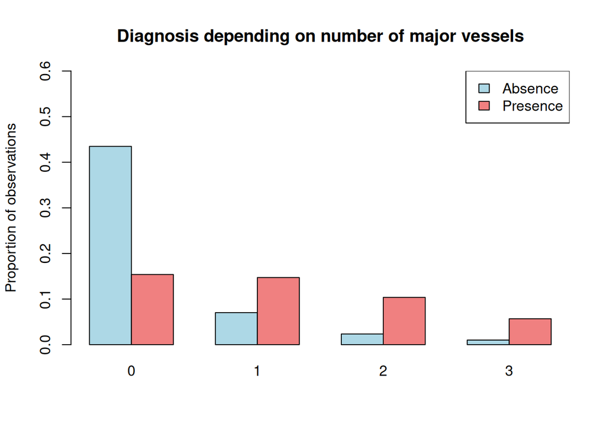

```r
barplot(ca_Diagnosis_table_freqs,
        col = c('lightblue', 'lightcoral'),
        beside = TRUE,
        ylim = c(0, 0.6), ylab = "Proportion of observations", main = "Diagnosis depending on number of major vessels");legend(x = "topright",legend = unique(data_ca$num),  fill = c('lightblue', 'lightcoral'))
```

```r
#Fisher test
fisher.test(ca_Diagnosis_table, alternative = "two.sided") #significative
```

```
##
##  Fisher's Exact Test for Count Data
##
## data:  ca_Diagnosis_table
## p-value < 2.2e-16
## alternative hypothesis: two.sided
```

```r
assocstats(ca_Diagnosis_table)
```

```
##                     X^2 df   P(> X^2)
## Likelihood Ratio 75.508  3 3.3307e-16
## Pearson          71.843  3 1.6653e-15
##
## Phi-Coefficient   : NA
## Contingency Coeff.: 0.44
## Cramer's V        : 0.49
```

```r
#Chi-squared test
res<-chisq.test(ca_Diagnosis_table)
res
```

```
##
##  Pearson's Chi-squared test
##
## data:  ca_Diagnosis_table
## X-squared = 71.843, df = 3, p-value = 1.72e-15
```

```r
res$observed
```

```
##
##              0   1   2   3
##   Absence  130  21   7   3
##   Presence  46  44  31  17
```

```r
res$expected
```

```
##
##                   0  1        2         3
##   Absence  94.76923 35 20.46154 10.769231
##   Presence 81.23077 30 17.53846  9.230769
```

```r
res$residuals
```

```
##
##                    0         1         2         3
##   Absence   3.618999 -2.366432 -2.975949 -2.367477
##   Presence -3.908966  2.556039  3.214393  2.557167
```

The analysis shows there is an statistical difference in diagnosis depending on the number of big vessels, showing having 0 big vessels can be a protecting factor and that having major vessels colored can be a risk factor, having more cases detected. Although it doesn’t seem like there is a big difference between having one, two or three major vessels.

##### Thalassemia (thal) and Diagnosis of heart disease (num)

We have to use the subset “data_thal” for this analysis as it is the one that does not have NA’s in the variable thal.

```r
# Absolute Frequences
thal_Diagnosis_table<-table(data_thal$num,data_thal$thal)
(thal_Diagnosis_table_total <- addmargins(thal_Diagnosis_table))
```

```
##
##            Normal Fixed defect Reversable defect Sum
##   Absence     129            6                28 163
##   Presence     37           12                89 138
##   Sum         166           18               117 301
```

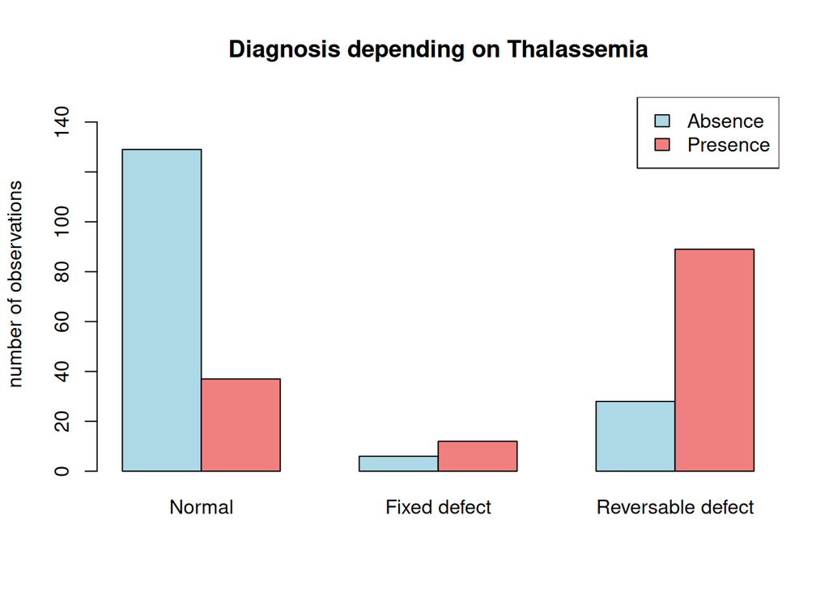

```r
barplot(thal_Diagnosis_table,
        col = c('lightblue', 'lightcoral'),
        beside = TRUE,
        ylim = c(0, 150), ylab = "number of observations", main = "Diagnosis depending on Thalassemia");legend(x = "topright",legend = unique(data_thal$num),  fill = c('lightblue', 'lightcoral'))
```

```r
#Relative Frequences tables
(thal_Diagnosis_table_freqs <- prop.table(thal_Diagnosis_table))
```

```
##
##                Normal Fixed defect Reversable defect
##   Absence  0.42857143   0.01993355        0.09302326
##   Presence 0.12292359   0.03986711        0.29568106
```

```r
(thal_Diagnosis_table_freqs_total <- addmargins(thal_Diagnosis_table_freqs))
```

```
##
##                Normal Fixed defect Reversable defect        Sum
##   Absence  0.42857143   0.01993355        0.09302326 0.54152824
##   Presence 0.12292359   0.03986711        0.29568106 0.45847176
##   Sum      0.55149502   0.05980066        0.38870432 1.00000000
```

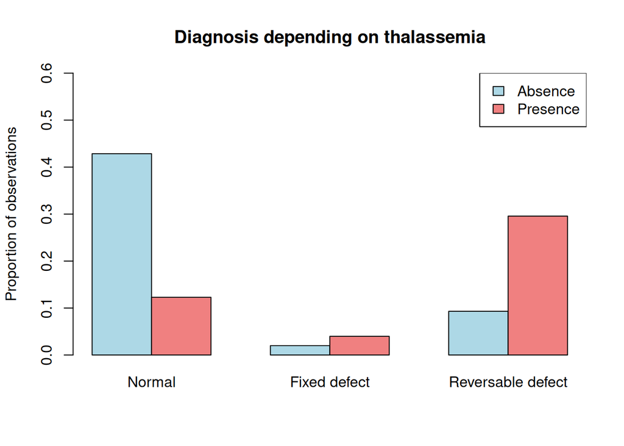

```r
barplot(thal_Diagnosis_table_freqs,
        col = c('lightblue', 'lightcoral'),
        beside = TRUE,
        ylim = c(0, 0.6), ylab = "Proportion of observations", main = "Diagnosis depending on thalassemia");legend(x = "topright",legend = unique(data_thal$num),  fill = c('lightblue', 'lightcoral'))
```

```r
#Fisher test
fisher.test(thal_Diagnosis_table, alternative = "two.sided") #significative
```

```
##
##  Fisher's Exact Test for Count Data
##
## data:  thal_Diagnosis_table
## p-value < 2.2e-16
## alternative hypothesis: two.sided
```

```r
assocstats(thal_Diagnosis_table)
```

```
##                     X^2 df P(> X^2)
## Likelihood Ratio 87.373  2        0
## Pearson          83.290  2        0
##
## Phi-Coefficient   : NA
## Contingency Coeff.: 0.466
## Cramer's V        : 0.526
```

```r
#Chi-squared test
res<-chisq.test(thal_Diagnosis_table)
res
```

```
##
##  Pearson's Chi-squared test
##
## data:  thal_Diagnosis_table
## X-squared = 83.29, df = 2, p-value < 2.2e-16
```

```r
res$observed
```

```
##
##            Normal Fixed defect Reversable defect
##   Absence     129            6                28
##   Presence     37           12                89
```

```r
res$expected
```

```
##
##              Normal Fixed defect Reversable defect
##   Absence  89.89369     9.747508           63.3588
##   Presence 76.10631     8.252492           53.6412
```

```r
res$residuals
```

```
##
##               Normal Fixed defect Reversable defect
##   Absence   4.124604    -1.200317         -4.442159
##   Presence -4.482667     1.304518          4.827790
```

The analysis shows there is an statistical difference in diagnosis depending on the thalassemia diagnosis. We can see how the biggest difference happens between not having thalassemia (Normal) and having a Reversable defect. We do not see a big impact of being diagnosed with a big defect but this could be because of the small sample size in this group, although it does show an increment in the diagnosis of heart disease as the reversable defect group.

# 2 Difference in mortality rates in hospitalized COVID-19 patients

Using the supplementary material from the [Difference in mortality rates in hospitalized COVID-19 patients identified by cytokine profile clustering using a machine learning approach: An outcome prediction alternative](https://www.frontiersin.org/articles/10.3389/fmed.2022.987182/full), perform the following tasks

## Treatment of the data

```r
#libraries needed
library(readxl)
library(ggplot2)
library(ggpubr)
library(RColorBrewer)
library(dplyr)
library(gridExtra)
#Opening both data tables
Table1 <- read_excel("data_ex2/Table1.XLSX",
    na = "NI", skip = 1)

View(Table1)
```

For many variables, the names had spaces so we removed them. They also had errors like numbers in classified variables.

#### Analyzing age

```r
class(Table1$Age)
```

```
## [1] "numeric"
```

```r
summary(Table1$Age)
```

```
##    Min. 1st Qu.  Median    Mean 3rd Qu.    Max.
##      25      50      60      60      71      97
```

```r
table(is.na(Table1$Age))
```

```
##
## FALSE
##   214
```

Age is correctly defined as numerical, and has a normal range as seen in the summary. Added to this, there are no NAs found.

#### Analyzing NIV

```r
#Renaming the variable so that it does not have spaces
Table1$useNIV<-Table1$`Use of NIV`
class(Table1$useNIV)
```

```
## [1] "character"
```

```r
table(Table1$useNIV)
```

```
##
##   8  No Yes
##   1  95 118
```

```r
# Taking out value 8 from the NIV variable
Table1<-Table1[Table1$useNIV !=8,]
table(Table1$useNIV)
```

```
##
##  No Yes
##  95 118
```

The use of NIV had an 8 instead of No or Yes, so we removed this value.

#### Analyzing AMV

```r
#Renaming the variable so that it does not have spaces
Table1$useAMV<-Table1$`Use of AMV`
class(Table1$useAMV)
```

```
## [1] "character"
```

```r
table(Table1$useAMV)
```

```
##
##  No Yes
## 154  59
```

The use of AMV is correctly characterized as a character and we see using a table that all values are either Yes or No.

#### Analyzing ARDS

```r
#Renaming the variable so that it does not have spaces
Table1$Diagnosis_ARDS<-Table1$`ARDS Diagnosis`
class(Table1$Diagnosis_ARDS)
```

```
## [1] "character"
```

```r
table(Table1$Diagnosis_ARDS)
```

```
##
##   4  No Yes
##   1  97 115
```

```r
# Taking out value 8 from the NIV variable
Table1<-Table1[Table1$Diagnosis_ARDS !=4,]
table(Table1$Diagnosis_ARDS)
```

```
##
##  No Yes
##  97 115
```

The ARDS diagnosis variable had a 4 instead of No or Yes, so we removed this value.

#### Analyzing Death

```r
table(Table1$Death)
```

```
##
##   3  No Yes
##   1 152  59
```

```r
Table1 <- Table1[Table1$Death != 3, ]   # Taking out the value "3"
table(Table1$Death)
```

```
##
##  No Yes
## 152  59
```

The Death variable had a 3 instead of No or Yes, so we removed this value.

#### Analyzing Gender

```r
table(Table1$Gender)
```

```
##
##  72   F   M
##   1  66 144
```

```r
Table1 <- Table1[Table1$Gender != 72, ]
table(Table1$Gender)
```

```
##
##   F   M
##  66 144
```

The Gender variable had a 72 instead of F or M, so we removed this value.

#### Analyzing Admission to UCI

```r
#Correcting the mistake in the name
Table1$Admission_to_UCI<-Table1$`Admission to ICU`
table(Table1$Admission_to_UCI)
```

```
##
## 4,5Yes    5.9     No    Yes
##      1      1    145     63
```

```r
Table1 <- Table1[Table1$Admission_to_UCI != c("4,5Yes"), ]#taking out 4.5Yes values
Table1 <- Table1[Table1$Admission_to_UCI != "5.9", ] #taking out 5.9 values
table(Table1$Admission_to_UCI)
```

```
##
##  No Yes
## 145  63
```

The Admission to Uci variable had a 4.5Yes value and a 5.9 value instead of No or Yes 2, so we removed this values.

#### Taking out duplicates

```r
#See if any of the IDs are duplicated
Table1[duplicated(Table1$ID), ]
```

```
## # A tibble: 8 × 22
##   ID              Age Gender BMI      `Syntoms onset`     `Hospitalization date`
##   <chr>         <dbl> <chr>  <chr>    <dttm>              <dttm>
## 1 COAG-HSJD-086    77 M      24.741   2020-08-22 00:00:00 2020-08-24 00:00:00
## 2 COAG-HSJD-136    33 M      34.5     2020-07-07 00:00:00 2020-07-14 00:00:00
## 3 COAG-HSJD-160    54 M      <NA>     2020-08-02 00:00:00 2020-08-07 00:00:00
## 4 COAG-HSJD-197    52 M      33       2020-07-28 00:00:00 2020-08-01 00:00:00
## 5 COAG-HSJD-222    71 M      <NA>     2020-08-02 00:00:00 2020-08-04 00:00:00
## 6 COAG-HSJD-225    35 M      <NA>     2020-08-03 00:00:00 2020-08-11 00:00:00
## 7 COAG-HSJD-243    62 M      <NA>     2020-07-30 00:00:00 2020-08-06 00:00:00
## 8 COAG-HSJD-244    52 M      36.7299… 2020-07-30 00:00:00 2020-08-07 00:00:00
## # ℹ 16 more variables: `Admission to ICU` <chr>, `Days in ICU` <dbl>,
## #   `ARDS Diagnosis` <chr>, `Days with ARDS` <dbl>, `CRS Diagnosis` <chr>,
## #   `Days with CRS` <dbl>, `Use of NIV` <chr>, `Days with NIV` <dbl>,
## #   `Use of AMV` <chr>, `Days with AMV` <dbl>, `Days of hospitalization` <dbl>,
## #   Death <chr>, useNIV <chr>, useAMV <chr>, Diagnosis_ARDS <chr>,
## #   Admission_to_UCI <chr>
```

```r
#Remove the duplicated records based on the ID column
unique_Table1 <- Table1[!duplicated(Table1$ID), ]
#Remove the remaining record of the duplicates where the data is not equal between the duplicates, COAG-HSJD-197, COAG-HSJD-222(diff date?), COAG-HSJD-243 (date?), COAG-HSJD-244.
correct_Table1 <- unique_Table1[!unique_Table1$ID %in% c("COAG-HSJD-197", "COAG-HSJD-222", "COAG-HSJD-243", "COAG-HSJD-244"), ]
```

## Reproduce Figure 1 from the publication

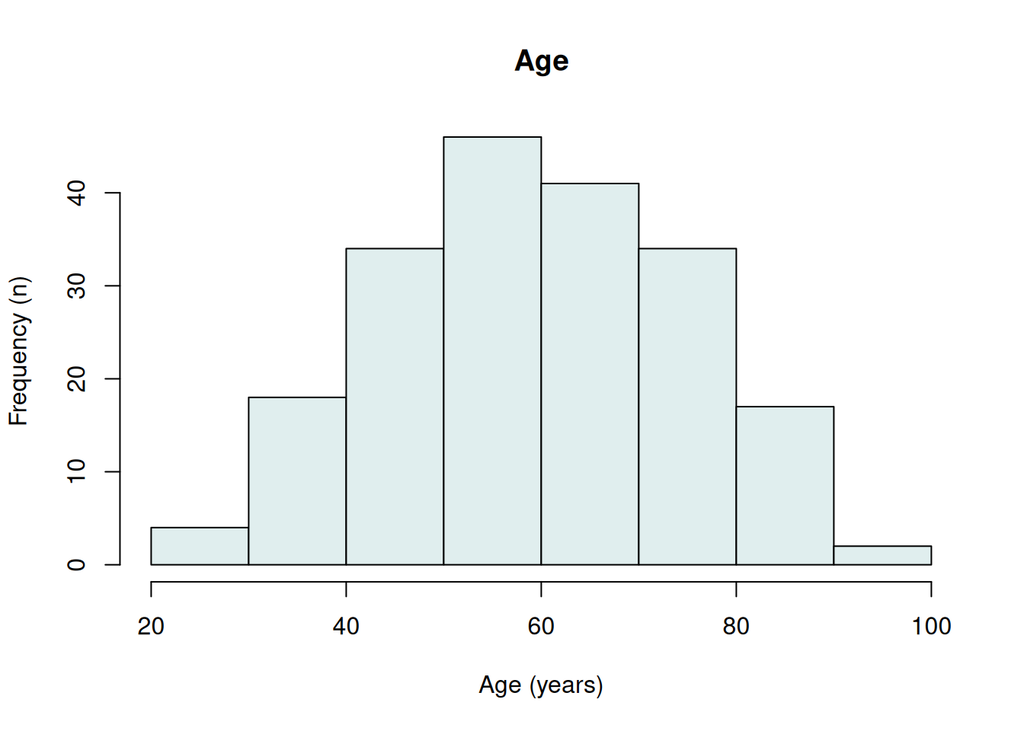

```r
##Reproduction of Figure 1.A: Age barplot
age_barplot <- hist(correct_Table1$Age, col = "azure2", xlab = "Age (years)", ylab = "Frequency (n)", main = "Age")
```

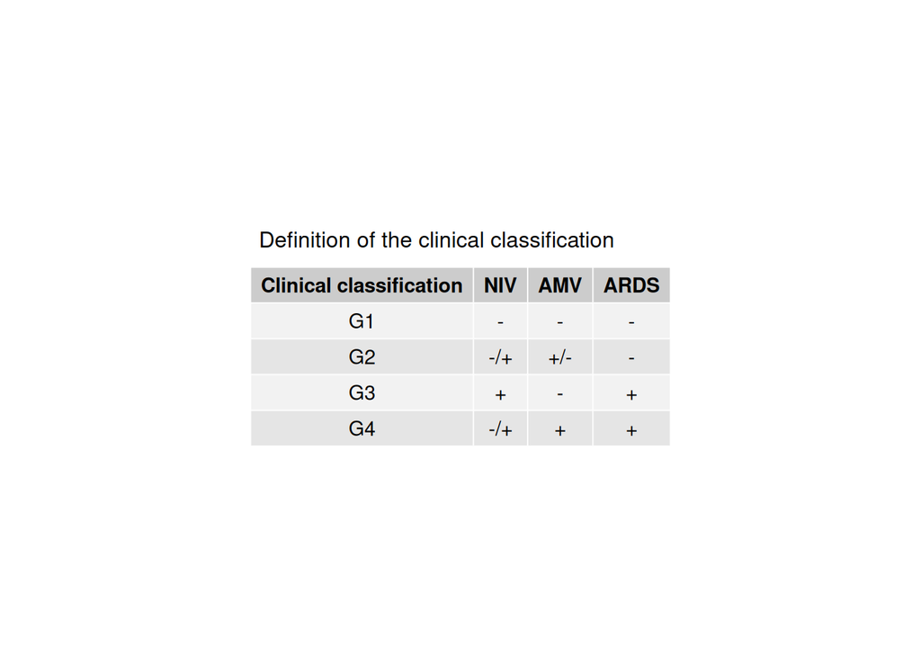

```r
## Reproduction of Figure 1.B: Clinical classification table
#Create the table
clinical_class <- data.frame(c("Clinical classification", "G1", "G2", "G3", "G4"),
                              c("NIV", "-","-/+","+", "-/+"),
                              c("AMV", "-","+/-","-", "+"),
                              c("ARDS", "-","-","+","+"))
colnames(clinical_class) <- unlist(clinical_class[1,])
clinical_class <- clinical_class[-1,]
#Represent the table with the necessary aesthetic parameters
class_tab <- ggtexttable(clinical_class,
                          rows = NULL,
                          cols = colnames(clinical_class),
                          vp = NULL,
                          theme = ttheme(),
                          )
#Add a title to the table
classification_table <- tab_add_title(tab = class_tab, text = "Definition of the clinical classification")
#Printing the classification table
classification_table
```

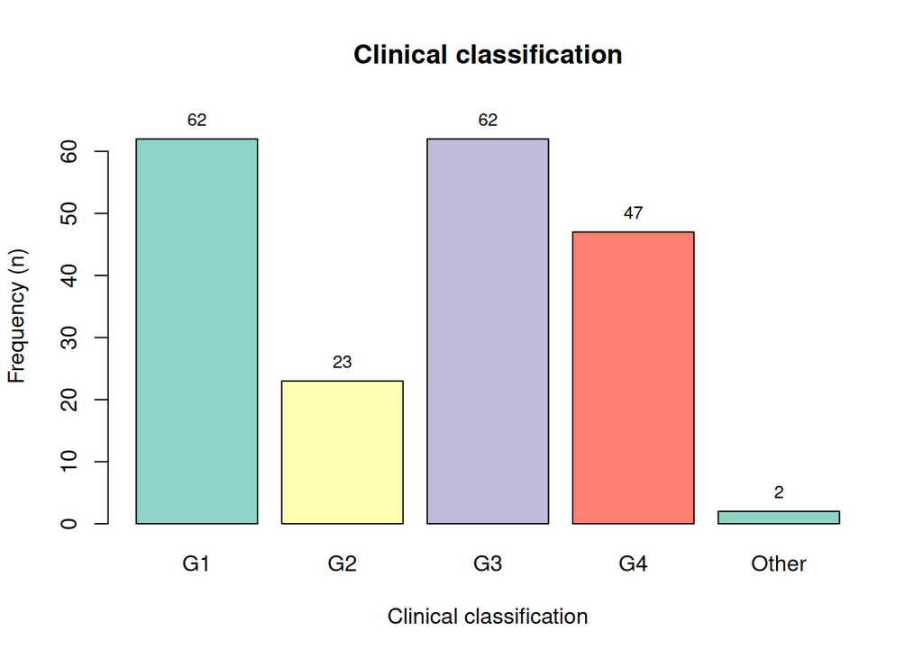

```r
## Reproduction of the figure 1.C: Barplot of Groups
#Add a new column for the clinical classification
correct_Table1 <- correct_Table1 %>%
  mutate(
    Group = case_when(
      `Use of NIV` == "No" & `Use of AMV` == "No" & `ARDS Diagnosis` == "No" ~ "G1",
      (`Use of NIV` %in% c("No", "Yes")) & (`Use of AMV` %in% c("No", "Yes")) & `ARDS Diagnosis` == "No" ~ "G2",
      `Use of NIV` == "Yes" & `Use of AMV` == "No" & `ARDS Diagnosis` == "Yes" ~ "G3",
      (`Use of NIV` %in% c("No", "Yes")) & `Use of AMV` == "Yes" & `ARDS Diagnosis` == "Yes" ~ "G4",
      TRUE ~ "Other"
    )
  )

#Create barplot with the specific parameters

# Create table with frequences
freq_table_Group <- table(correct_Table1$Group)

# Creating the barplot, and capturing the positions of the bars
Barplot_groups<-text(x=barplot(freq_table_Group,
                         xlab = "Clinical classification",
                         ylab = "Frequency (n)",
                         main = "Clinical classification",
                         col = brewer.pal(4, "Set3"),
                         ylim = c(0, max(freq_table_Group) + 5)) ,
     y = as.numeric(freq_table_Group),
     labels = as.numeric(freq_table_Group),
     pos = 3,
     cex = 0.8,
     col = "black")
```

```r
#Reproduction of figure 1.D: Vital status barplot
table(correct_Table1$Death)
```

```
##
##  No Yes
## 141  55
```

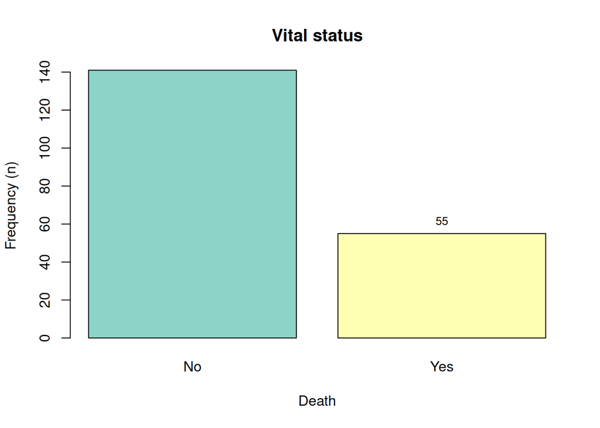

```r
death_fig <-text( x=barplot(table(correct_Table1$Death),
                      xlab =  "Death", ylab = "Frequency (n)",
                      main = "Vital status",
                      col = c(brewer.pal(3, "Set3")) ),
                   y = as.numeric(table(correct_Table1$Death)),
     labels = as.numeric(table(correct_Table1$Death)),
     pos = 3,
     cex = 0.8,
     col = "black")
```

## Reproduce Figure 2 from the publication

but instead of representing the clusters in the annotation, represent the groups (G1 to G4)

```r
Table_2 <- read_excel("data_ex2/Table2.XLSX", col_names = FALSE, na = "NI",skip=1)
#Setting the first column as ID
names(Table_2)[1]
```

```
## [1] "...1"
```

```r
colnames(Table_2)[1] <- "ID"

#See if any of the IDs are duplicated
id_counts <- table(Table_2$ID)
repeated_ids <- names(id_counts[id_counts > 1])
print(repeated_ids)
```

```
## [1] "COAG-HSJD-086" "COAG-HSJD-136"
```

```r
#"COAG-HSJD-086" "COAG-HSJD-136" are duplicate. Remove both records of the duplicate since the data different between them.
unique_Table2 <- Table_2[!Table_2$ID %in% c("COAG-HSJD-086", "COAG-HSJD-136"), ]
library(tidyr)
extended_Table2 <- unique_Table2 %>% fill(ID , .direction = "down")
str(extended_Table2)
```

```
## tibble [442 × 27] (S3: tbl_df/tbl/data.frame)
##  $ ID   : chr [1:442] NA "COAG-HSJD-001" "COAG-HSJD-002" "COAG-HSJD-003" ...
##  $ ...2 : chr [1:442] "Day" "1" "1" "1" ...
##  $ ...3 : chr [1:442] "IL-1β" "0" "0" "0" ...
##  $ ...4 : chr [1:442] "IL-6" "4.5999999999999996" "0.5" "147.69999999999999" ...
##  $ ...5 : chr [1:442] "IL-10" "4.0599999999999996" "9.16" "4.7" ...
##  $ ...6 : chr [1:442] "IFN-ɑ" "2.69" "2.52" "0.4" ...
##  $ ...7 : chr [1:442] "TNF-ɑ" "0.72" "1.4" "0" ...
##  $ ...8 : chr [1:442] "IL-8" "37.619999999999997" "8.66" "133.52510000000001" ...
##  $ ...9 : chr [1:442] "G-CSF" "3.7" "2.52" "10.344060000000001" ...
##  $ ...10: chr [1:442] "IFN-γ" "4.68" "3.72" "3.6417510000000002" ...
##  $ ...11: chr [1:442] "CCL3" "4.07" "5.07" "20.068390000000001" ...
##  $ ...12: chr [1:442] "CXCL10" "2387.96" "1490.02" "2135.7710000000002" ...
##  $ ...13: chr [1:442] "CCL2" "58.88" "13.74" "901.47990000000004" ...
##  $ ...14: chr [1:442] "IL-38" "566.79" "655.42" "888.09339999999997" ...
##  $ ...15: chr [1:442] "PT" "13.7" "13.2" "13" ...
##  $ ...16: chr [1:442] "TTP" "77" "82" "84" ...
##  $ ...17: chr [1:442] "D-Dimer" "359" NA "1986" ...
##  $ ...18: chr [1:442] "Fibrinogen" "707" NA "518" ...
##  $ ...19: chr [1:442] "CRP" "26.47" "1.1200000000000001" "36.92" ...
##  $ ...20: chr [1:442] "Procalcitonin" "0.21" "0.113" "3.67" ...
##  $ ...21: chr [1:442] "Ferritin" "547.6" "509.1" ">4000" ...
##  $ ...22: chr [1:442] "Hemoglobin (g/dL)" "11.9" "13.7" "13.9" ...
##  $ ...23: chr [1:442] "Platelets (units/µl)" "200" "303" "116" ...
##  $ ...24: chr [1:442] "Leucocytes (units/mm^3)" "5.3" "127" "6.26" ...
##  $ ...25: chr [1:442] "Lymphocytes (units/mm^3)" "0.53" "1.1399999999999999" "0.93" ...
##  $ ...26: chr [1:442] "Neutrophils (units/mm^3)" "4.18" "10.94" "5.17" ...
##  $ ...27: chr [1:442] "Eritrocytes (millions/microliter)" "4.12" "5.13" "4.26" ...
```

```r
table(extended_Table2$ID, useNA = "ifany")
```

```
##
## COAG-HSDJ-202 COAG-HSDJ-203 COAG-HSDJ-206 COAG-HSJD-001 COAG-HSJD-002
##             2             3             7             1             1
## COAG-HSJD-003 COAG-HSJD-004 COAG-HSJD-005 COAG-HSJD-006 COAG-HSJD-007
##             6             1             1             6             8
## COAG-HSJD-008 COAG-HSJD-010 COAG-HSJD-011 COAG-HSJD-012 COAG-HSJD-013
##             6             1             1             1             1
## COAG-HSJD-014 COAG-HSJD-015 COAG-HSJD-016 COAG-HSJD-017 COAG-HSJD-018
##             4             1             1             1             6
## COAG-HSJD-019 COAG-HSJD-021 COAG-HSJD-022 COAG-HSJD-023 COAG-HSJD-024
##             1             1             2             5             1
## COAG-HSJD-025 COAG-HSJD-026 COAG-HSJD-027 COAG-HSJD-028 COAG-HSJD-029
##             2             1             1             6             1
## COAG-HSJD-030 COAG-HSJD-031 COAG-HSJD-032 COAG-HSJD-033 COAG-HSJD-034
##             1             3             1             7             7
## COAG-HSJD-035 COAG-HSJD-036 COAG-HSJD-037 COAG-HSJD-038 COAG-HSJD-039
##             1             1             1             8             1
## COAG-HSJD-040 COAG-HSJD-042 COAG-HSJD-044 COAG-HSJD-046 COAG-HSJD-047
##             1             1             1             1             1
## COAG-HSJD-050 COAG-HSJD-051 COAG-HSJD-052 COAG-HSJD-053 COAG-HSJD-054
##             1             1             2             9             1
## COAG-HSJD-055 COAG-HSJD-056 COAG-HSJD-057 COAG-HSJD-058 COAG-HSJD-059
##             8             5             1             1             1
## COAG-HSJD-061 COAG-HSJD-062 COAG-HSJD-063 COAG-HSJD-065 COAG-HSJD-066
##             1             1             7             1             1
## COAG-HSJD-067 COAG-HSJD-068 COAG-HSJD-069 COAG-HSJD-070 COAG-HSJD-072
##             1             1             7             9             5
## COAG-HSJD-073 COAG-HSJD-074 COAG-HSJD-075 COAG-HSJD-076 COAG-HSJD-077
##             1             4             1             1             8
## COAG-HSJD-078 COAG-HSJD-079 COAG-HSJD-080 COAG-HSJD-081 COAG-HSJD-082
##             8             1             1             1             1
## COAG-HSJD-083 COAG-HSJD-084 COAG-HSJD-085 COAG-HSJD-088 COAG-HSJD-089
##             9             6             1             4             1
## COAG-HSJD-090 COAG-HSJD-091 COAG-HSJD-092 COAG-HSJD-093 COAG-HSJD-094
##             1             1             1             1             3
## COAG-HSJD-096 COAG-HSJD-098 COAG-HSJD-099 COAG-HSJD-100 COAG-HSJD-102
##             5             1             1             1             1
## COAG-HSJD-103 COAG-HSJD-104 COAG-HSJD-107 COAG-HSJD-108 COAG-HSJD-109
##             1             1             3             6             9
## COAG-HSJD-110 COAG-HSJD-111 COAG-HSJD-113 COAG-HSJD-114 COAG-HSJD-115
```

[output cut: 24 more lines]

```
##             1             1             1             1             2
## COAG-HSJD-210 COAG-HSJD-212 COAG-HSJD-213 COAG-HSJD-214 COAG-HSJD-215
##             1             1             7             2             1
## COAG-HSJD-216 COAG-HSJD-217 COAG-HSJD-218 COAG-HSJD-219 COAG-HSJD-220
##             1             1             1             1             1
## COAG-HSJD-221 COAG-HSJD-222 COAG-HSJD-223 COAG-HSJD-224 COAG-HSJD-225
##             1             1             1             2             1
## COAG-HSJD-227 COAG-HSJD-228 COAG-HSJD-229 COAG-HSJD-231 COAG-HSJD-232
##             5             1             1             1             1
## COAG-HSJD-233 COAG-HSJD-234 COAG-HSJD-235 COAG-HSJD-237 COAG-HSJD-238
##             1             1             1             2             1
## COAG-HSJD-239 COAG-HSJD-240 COAG-HSJD-242 COAG-HSJD-244 COAG-HSJD-246
##             1             2             1             2             1
## COAG-HSJD-248 COAG-HSJD-249          <NA>
##             1             1             1
```

```r
#In order to classify the records of table 2 by the clinical classification,we need to see if the IDs are the same between tables 1 and 2
# IDs in Table1 but not in Table2
missing_in_Table1 <- correct_Table1$ID[!correct_Table1$ID %in% extended_Table2$ID]
missing_in_Table1
```

```
##  [1] "COAG-HSJD-086" "COAG-HSJD-087" "COAG-HSJD-106" "COAG-HSJD-116"
##  [5] "COAG-HSJD-125" "COAG-HSJD-126" "COAG-HSJD-132" "COAG-HSJD-136"
##  [9] "COAG-HSJD-137" "COAG-HSJD-148" "COAG-HSJD-166" "COAG-HSJD-193"
## [13] "COAG-HSJD-202" "COAG-HSJD-203" "COAG-HSJD-205" "COAG-HSJD-206"
## [17] "COAG-HSJD-211"
```

```r
#Since they are not the same we will remove the Ids from table2 missing in table 1
pruned_Table2 <- extended_Table2[extended_Table2$ID %in% correct_Table1$ID, ]

#There are Ids with different number of days, we will calculate the values as the median of each set of days for each ID, since that is how they did it in the paper.
str(pruned_Table2)
```

```
## tibble [413 × 27] (S3: tbl_df/tbl/data.frame)
##  $ ID   : chr [1:413] "COAG-HSJD-001" "COAG-HSJD-002" "COAG-HSJD-003" "COAG-HSJD-003" ...
##  $ ...2 : chr [1:413] "1" "1" "1" "3" ...
##  $ ...3 : chr [1:413] "0" "0" "0" "0" ...
##  $ ...4 : chr [1:413] "4.5999999999999996" "0.5" "147.69999999999999" "169.5" ...
##  $ ...5 : chr [1:413] "4.0599999999999996" "9.16" "4.7" "0" ...
##  $ ...6 : chr [1:413] "2.69" "2.52" "0.4" "2.2815259999999999" ...
##  $ ...7 : chr [1:413] "0.72" "1.4" "0" "1.4033" ...
##  $ ...8 : chr [1:413] "37.619999999999997" "8.66" "133.52510000000001" "96.705349999999996" ...
##  $ ...9 : chr [1:413] "3.7" "2.52" "10.344060000000001" "13.041069999999999" ...
##  $ ...10: chr [1:413] "4.68" "3.72" "3.6417510000000002" "4.0869479999999996" ...
##  $ ...11: chr [1:413] "4.07" "5.07" "20.068390000000001" "5.975409" ...
##  $ ...12: chr [1:413] "2387.96" "1490.02" "2135.7710000000002" "1025.501" ...
##  $ ...13: chr [1:413] "58.88" "13.74" "901.47990000000004" "263.40839999999997" ...
##  $ ...14: chr [1:413] "566.79" "655.42" "888.09339999999997" "951.71619999999996" ...
##  $ ...15: chr [1:413] "13.7" "13.2" "13" "14.3" ...
##  $ ...16: chr [1:413] "77" "82" "84" "73" ...
##  $ ...17: chr [1:413] "359" NA "1986" "993" ...
##  $ ...18: chr [1:413] "707" NA "518" "707" ...
##  $ ...19: chr [1:413] "26.47" "1.1200000000000001" "36.92" "37.07" ...
##  $ ...20: chr [1:413] "0.21" "0.113" "3.67" "0" ...
##  $ ...21: chr [1:413] "547.6" "509.1" ">4000" "227764.2" ...
##  $ ...22: chr [1:413] "11.9" "13.7" "13.9" "12.3" ...
##  $ ...23: chr [1:413] "200" "303" "116" "114" ...
##  $ ...24: chr [1:413] "5.3" "127" "6.26" "2.33" ...
##  $ ...25: chr [1:413] "0.53" "1.1399999999999999" "0.93" "0.28000000000000003" ...
##  $ ...26: chr [1:413] "4.18" "10.94" "5.17" "1.94" ...
##  $ ...27: chr [1:413] "4.12" "5.13" "4.26" "3.81" ...
```

```r
pruned_Table2[, 2:27] <- lapply(pruned_Table2[, 2:27], as.numeric)
median_Table2 <- pruned_Table2 %>%
 mutate(ID = as.character(ID)) %>%
 group_by(ID) %>%
 summarise(across(where(is.numeric), median, na.rm = TRUE))
library(mice)
#Impute the missing values
imputed_data <- mice(median_Table2)
summary(imputed_data)
```

```
## Class: mids
## Number of multiple imputations:  5
## Imputation methods:
##    ID  ...2  ...3  ...4  ...5  ...6  ...7  ...8  ...9 ...10 ...11 ...12 ...13
##    ""    ""    "" "pmm"    ""    ""    ""    ""    ""    ""    ""    ""    ""
## ...14 ...15 ...16 ...17 ...18 ...19 ...20 ...21 ...22 ...23 ...24 ...25 ...26
##    "" "pmm" "pmm" "pmm" "pmm" "pmm" "pmm" "pmm" "pmm" "pmm" "pmm" "pmm"    ""
## ...27
## "pmm"
## PredictorMatrix:
##      ID ...2 ...3 ...4 ...5 ...6 ...7 ...8 ...9 ...10 ...11 ...12 ...13 ...14
## ID    0    1    1    1    1    1    1    1    1     1     1     1     1     1
## ...2  0    0    1    1    1    1    1    1    1     1     1     1     1     1
## ...3  0    1    0    1    1    1    1    1    1     1     1     1     1     1
## ...4  0    1    1    0    1    1    1    1    1     1     1     1     1     1
## ...5  0    1    1    1    0    1    1    1    1     1     1     1     1     1
## ...6  0    1    1    1    1    0    1    1    1     1     1     1     1     1
##      ...15 ...16 ...17 ...18 ...19 ...20 ...21 ...22 ...23 ...24 ...25 ...26
## ID       1     1     1     1     1     1     1     1     1     1     1     0
## ...2     1     1     1     1     1     1     1     1     1     1     1     0
## ...3     1     1     1     1     1     1     1     1     1     1     1     0
## ...4     1     1     1     1     1     1     1     1     1     1     1     0
## ...5     1     1     1     1     1     1     1     1     1     1     1     0
## ...6     1     1     1     1     1     1     1     1     1     1     1     0
##      ...27
## ID       1
## ...2     1
## ...3     1
## ...4     1
## ...5     1
## ...6     1
## Number of logged events:  2
##   it im dep      meth   out
## 1  0  0      constant    ID
## 2  0  0     collinear ...26
```

```r
completed_Table2 <- complete(imputed_data, action = 1)

#Add the column of the clinical classification from Table 1 to the IDs from Table 2
group_Table2 <- merge(completed_Table2, correct_Table1[, c("ID", "Group")], by = "ID", all.x = TRUE)

#Subset the columns that will be used for the heatmap
colnames(group_Table2)
```

```
##  [1] "ID"    "...2"  "...3"  "...4"  "...5"  "...6"  "...7"  "...8"  "...9"
## [10] "...10" "...11" "...12" "...13" "...14" "...15" "...16" "...17" "...18"
## [19] "...19" "...20" "...21" "...22" "...23" "...24" "...25" "...26" "...27"
## [28] "Group"
```

```r
heatmap_table <- group_Table2[, c(1, 28, 3:14)]
# Fix column names to remove special characters
colnames(heatmap_table) <- gsub("β", "b", colnames(heatmap_table))
colnames(heatmap_table) <- gsub("γ", "g", colnames(heatmap_table))
colnames(heatmap_table) <- gsub("ɑ", "a", colnames(heatmap_table))
colnames(heatmap_table) #Checking the changes have been performed correctly
```

```
##  [1] "ID"    "Group" "...3"  "...4"  "...5"  "...6"  "...7"  "...8"  "...9"
## [10] "...10" "...11" "...12" "...13" "...14"
```

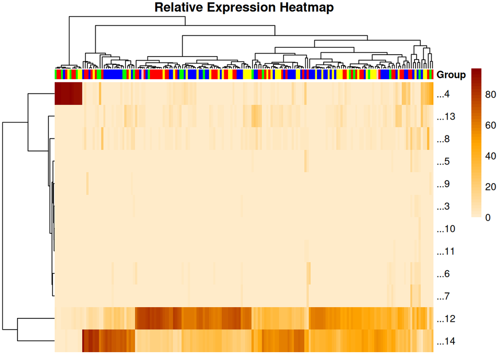

```r
# Transpose the data so genes are rows and patients are columns
heatmap_data <- t(heatmap_table[, 3:14]) # Gene expression matrix
colnames(heatmap_data) <- heatmap_table$ID  # Assign patient IDs as column names

#Scale the gene expression values
heatmap_data <-sweep(heatmap_data, 2, colSums(heatmap_data), FUN = "/") * 100

# Prepare the annotation for which Ids are from which groups
groups_info <- heatmap_table$Group
annotation <- data.frame(Group = groups_info)
rownames(annotation) <- heatmap_table$ID  # Ensure rownames of annotation match patient IDs



library(pheatmap)
library(RColorBrewer)

pheatmap(
  heatmap_data,
  cluster_rows = TRUE,
  cluster_cols = TRUE,
  scale = "none",
  color =  colorRampPalette(c("#FFEBC9", "orange", "darkred"))(50),
  main = "Relative Expression Heatmap",
  annotation_col = annotation,
  annotation_colors = list( Group = c(G1 = "red", G2 = "green", G3 = "blue", G4 = "yellow", Other = "pink")
),
  annotation_legend = FALSE,
  annotation_names_col = TRUE,
  show_colnames = FALSE,
)
```

## Improve figure 2 of the publication

Add a second annotation with information of deathm and a third one with information of gender

```r
#Add the column of the gender and death from Table 1 to the IDs from Table 2
all_Table2 <- merge(group_Table2, correct_Table1[, c("ID", "Death", "Gender")], by = "ID", all.x = TRUE)

#Subset the columns that will be used for the heatmap
colnames(all_Table2)
```

```
##  [1] "ID"     "...2"   "...3"   "...4"   "...5"   "...6"   "...7"   "...8"
##  [9] "...9"   "...10"  "...11"  "...12"  "...13"  "...14"  "...15"  "...16"
## [17] "...17"  "...18"  "...19"  "...20"  "...21"  "...22"  "...23"  "...24"
## [25] "...25"  "...26"  "...27"  "Group"  "Death"  "Gender"
```

```r
all_heatmap_table <- all_Table2[, c(1, 28, 29,30, 3:14)]
# Fix column names to remove special characters
colnames(all_heatmap_table) <- gsub("β", "b", colnames(all_heatmap_table))
colnames(all_heatmap_table) <- gsub("γ", "g", colnames(all_heatmap_table))
colnames(all_heatmap_table) <- gsub("ɑ", "a", colnames(all_heatmap_table))
colnames(all_heatmap_table) #Checking the changes have been performed correctly
```

```
##  [1] "ID"     "Group"  "Death"  "Gender" "...3"   "...4"   "...5"   "...6"
##  [9] "...7"   "...8"   "...9"   "...10"  "...11"  "...12"  "...13"  "...14"
```

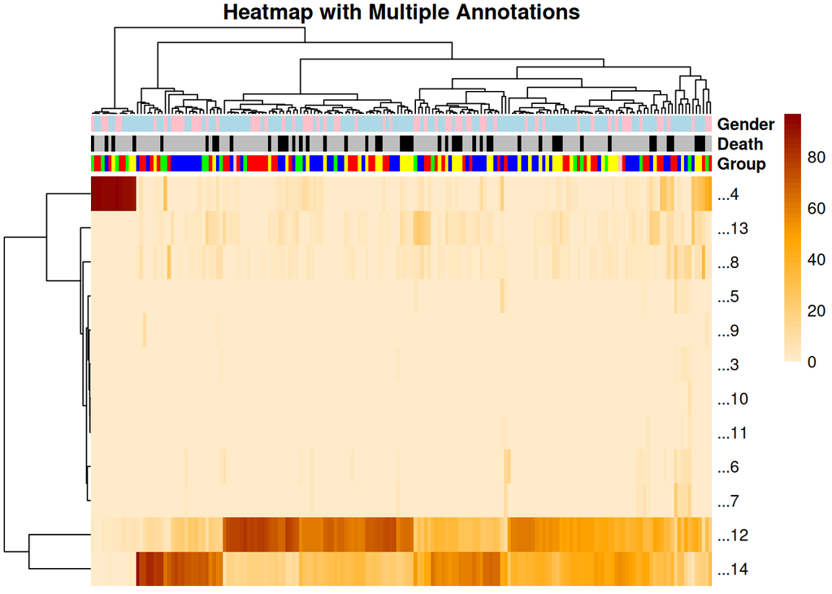

```r
# Transpose the data so genes are rows and patients are columns
all_heatmap_data <- t(all_heatmap_table[, 5:16]) # Gene expression matrix
colnames(all_heatmap_data) <- all_heatmap_table$ID  # Assign patient IDs as column names

#Scale the gene expression values
all_heatmap_data <-sweep(all_heatmap_data, 2, colSums(all_heatmap_data), FUN = "/") * 100

# Add death and gender columns to the annotation data frame
groups_info <- all_heatmap_table$Group
death_info <- all_heatmap_table$Death
gender_info <- all_heatmap_table$Gender

# Create the annotation data frame
annotation <- data.frame(
  Group = groups_info,
  Death = death_info,
  Gender = gender_info
)
rownames(annotation) <- all_heatmap_table$ID  # Ensure rownames match patient IDs


pheatmap(
  all_heatmap_data,
  cluster_rows = TRUE,
  cluster_cols = TRUE,
  scale = "none",
  color = colorRampPalette(c("#FFEBC9", "orange", "darkred"))(50),
  main = "Heatmap with Multiple Annotations",
  annotation_col = annotation,
  annotation_colors = list(
    Group = c(G1 = "red", G2 = "green", G3 = "blue", G4 = "yellow", Other = "pink"),
    Death = c(Yes = "black", No = "gray"),
    Gender = c(M = "lightblue", F = "pink")),
  annotation_legend = FALSE,
  annotation_names_col = TRUE,
  show_colnames = FALSE
)
```

# session info

R version 4.3.3 (2024-02-29) Platform: x86_64-pc-linux-gnu (64-bit) Running under: Ubuntu 24.04.1 LTS

Matrix products: default BLAS: /usr/lib/x86_64-linux-gnu/openblas-pthread/libblas.so.3 LAPACK: /usr/lib/x86_64-linux-gnu/openblas-pthread/libopenblasp-r0.3.26.so; LAPACK version 3.12.0

locale: [1] LC_CTYPE=en_US.UTF-8 LC_NUMERIC=C  
[3] LC_TIME=en_US.UTF-8 LC_COLLATE=en_US.UTF-8  
[5] LC_MONETARY=en_US.UTF-8 LC_MESSAGES=en_US.UTF-8  
[7] LC_PAPER=en_US.UTF-8 LC_NAME=C  
[9] LC_ADDRESS=C LC_TELEPHONE=C  
[11] LC_MEASUREMENT=en_US.UTF-8 LC_IDENTIFICATION=C

time zone: Europe/Madrid tzcode source: system (glibc)

attached base packages: [1] grid stats graphics grDevices utils datasets methods  
[8] base

other attached packages: [1] pheatmap_1.0.12 mice_3.17.0 tidyr_1.3.1 gridExtra_2.3  
[5] RColorBrewer_1.1-3 ggpubr_0.6.0 readxl_1.4.3 vcd_1.4-13  
[9] dplyr_1.1.4 ggplot2_3.5.1

loaded via a namespace (and not attached): [1] gtable_0.3.6 shape_1.4.6.1 xfun_0.48 bslib_0.8.0  
[5] rstatix_0.7.2 lattice_0.22-5 Rdpack_2.6.2 vctrs_0.6.5  
[9] tools_4.3.3 generics_0.1.3 tibble_3.2.1 fansi_1.0.6  
[13] pan_1.9 highr_0.11 jomo_2.7-6 pkgconfig_2.0.3  
[17] Matrix_1.6-5 lifecycle_1.0.4 compiler_4.3.3 farver_2.1.2  
[21] munsell_0.5.1 codetools_0.2-19 carData_3.0-5 htmltools_0.5.8.1 [25] sass_0.4.9 yaml_2.3.10 glmnet_4.1-8 Formula_1.2-5  
[29] nloptr_2.1.1 pillar_1.9.0 car_3.1-3 jquerylib_0.1.4  
[33] MASS_7.3-60.0.1 cachem_1.1.0 reformulas_0.4.0 iterators_1.0.14 [37] rpart_4.1.23 boot_1.3-30 abind_1.4-8 foreach_1.5.2  
[41] mitml_0.4-5 nlme_3.1-164 tidyselect_1.2.1 digest_0.6.37  
[45] purrr_1.0.2 labeling_0.4.3 splines_4.3.3 cowplot_1.1.3  
[49] fastmap_1.2.0 colorspace_2.1-1 cli_3.6.3 magrittr_2.0.3  
[53] survival_3.5-8 utf8_1.2.4 broom_1.0.7 withr_3.0.1  
[57] scales_1.3.0 backports_1.5.0 rmarkdown_2.28 nnet_7.3-19  
[61] lme4_1.1-36 ggsignif_0.6.4 cellranger_1.1.0 zoo_1.8-12  
[65] evaluate_1.0.0 knitr_1.48 rbibutils_2.3 lmtest_0.9-40  
[69] rlang_1.1.4 Rcpp_1.0.13 glue_1.8.0 minqa_1.2.8  
[73] rstudioapi_0.16.0 jsonlite_1.8.9 R6_2.5.1